# Practical Machine Learning Course Project

Francis D

April 23, 2016

## Introduction

In this project I decided to use the Random Forest Model to predict the classe variable as required in the assignment since this seems to be a classification problem. I split the original training data into a sub training as myTraindata and test data as myTestdata respectively. I removed columns with NA’s and other irrelevant variables. I then used confusion matrix to determine the accuracy of the model and finally used the model to predict the original test data.

## Loading Data and Packages Needed

```r
library(caret)
```

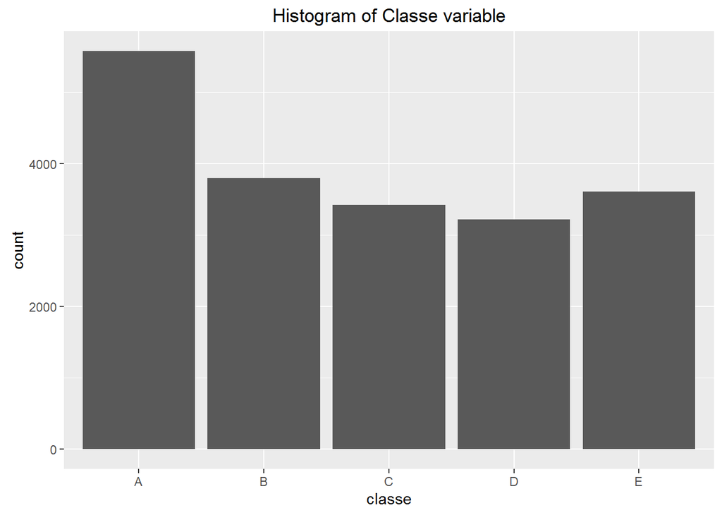

```r
library(ggplot2)

training <- read.csv(url("https://d396qusza40orc.cloudfront.net/predmachlearn/pml-training.csv"),na.strings=c("NA","#DIV/0",""))
testing <- read.csv(url("https://d396qusza40orc.cloudfront.net/predmachlearn/pml-testing.csv"),na.strings=c("NA","#DIV/0",""))

 qplot(classe,data=training,main="Histogram of Classe variable")
```

The dimenions of the training and the testing data are

```
## [1] 19622   160
```

```
## [1]  20 160
```

## Cleaning the Data

Removed columns full of NA’s and omitted the first seven columns since they would not be relevant in predicting the classe varaibles. This is done to both the training and testing sets to ensure the same variables.

```r
RemainingCols<- names(testing[,colSums(is.na(testing))== 0])[8:59]
TR<- training[ , c(RemainingCols,"classe")]#Original training set
TE<- testing[ , c(RemainingCols,"problem_id")]# Original Test set
```

## Splitting the Training Data(TR)

Here I split Training Data into sub Train and Test data respectively in oder to account for cross validation.

```r
set.seed(2465)

inTrain <- createDataPartition(TR$classe, p=0.7,list=FALSE)
myTraindata<- TR[inTrain,]
myTestdata <- TR[-inTrain,]
```

Again the dimensions of the training and test data are

```
## [1] 13737    53
```

```
## [1] 5885   53
```

## Building the Model

```r
CRF1 <- trainControl(method="cv", 5)##perfporming 5-fold cross validation
myModelRF<- train(classe~., data=myTraindata, method="rf", rtControl=CRF1, ntree = 250)
fitRF <- predict(myModelRF,myTestdata)

confusionMatrix(fitRF,myTestdata$classe)
```

```
## Confusion Matrix and Statistics
##
##           Reference
## Prediction    A    B    C    D    E
##          A 1673    6    0    0    0
##          B    0 1130    8    0    1
##          C    0    3 1015   18    1
##          D    0    0    3  946    7
##          E    1    0    0    0 1073
##
## Overall Statistics
##
##                Accuracy : 0.9918
##                  95% CI : (0.9892, 0.994)
##     No Information Rate : 0.2845
##     P-Value [Acc > NIR] : < 2.2e-16
##
##                   Kappa : 0.9897
##  Mcnemar's Test P-Value : NA
##
## Statistics by Class:
##
##                      Class: A Class: B Class: C Class: D Class: E
## Sensitivity            0.9994   0.9921   0.9893   0.9813   0.9917
## Specificity            0.9986   0.9981   0.9955   0.9980   0.9998
## Pos Pred Value         0.9964   0.9921   0.9788   0.9895   0.9991
## Neg Pred Value         0.9998   0.9981   0.9977   0.9963   0.9981
## Prevalence             0.2845   0.1935   0.1743   0.1638   0.1839
## Detection Rate         0.2843   0.1920   0.1725   0.1607   0.1823
## Detection Prevalence   0.2853   0.1935   0.1762   0.1624   0.1825
## Balanced Accuracy      0.9990   0.9951   0.9924   0.9896   0.9957
```

## Predicting the Original Test Data(TE)

```r
Submitresults<- predict(myModelRF,TE)
Submitresults
```

```
##  [1] B A B A A E D B A A B C B A E E A B B B
## Levels: A B C D E
```